# Lab 2: Enrichment Analyses

BMI 206

Wanjun Gu

10/27/2023

Import needed packages and set a random number seed

```r
#load packages
suppressPackageStartupMessages({
  suppressWarnings({


    if(!require("BiocManager", quietly = TRUE)){
      install.packages("BiocManager")
    }

    if(!require("regioneR")){
      BiocManager::install("regioneR")
      library("regioneR")
    }

    if(!require("BSgenome.Hsapiens.UCSC.hg19")){
      BiocManager::install("BSgenome.Hsapiens.UCSC.hg19")
      library("BSgenome.Hsapiens.UCSC.hg19")
    }

    if(!require("dplyr")){
      BiocManager::install("dplyr")
      library("dplyr")
    }
  })
})

set.seed(492357816)
```

Read in BED formatted region files: all tested regions and two sets of positives Note: these are in hg19 human genome assembly coordinates

```r
all=toGRanges(read.table("all.bed",sep="\t"))
hits1=toGRanges(read.table("hits1.bed",sep="\t"))
hits2=toGRanges(read.table("hits2.bed",sep="\t"))
```

**Q1. How many regions are in hits1? How many in hits2?** There are 140 regions in hist1 and 322 regions in hist2

```r
dim(as.data.frame(hits1@ranges))[1]
```

```
## [1] 140
```

```r
dim(as.data.frame(hits2@ranges))[1]
```

```
## [1] 322
```

**Q2. Are hits1 and hits2 proper subsets of all the tested regions? Check how many of each set overlaps a region in all.**

Identical regions in hits1 and hits2 can be found in all. This indicates that both hits1 and hits2 are subsets of all.

Code to identify overlaps

```r
(findOverlaps(all, hits1, type = "any") %>%
   as.data.frame() %>%
   dim())[1]
```

```
## [1] 141
```

```r
(findOverlaps(all, hits2, type = "any") %>%
    as.data.frame() %>%
    dim())[1]
```

```
## [1] 337
```

Code to identify exact identical regions.

```r
range_to_df = function(x){
  chr = as.vector(x@seqnames)
  dff = as.data.frame(x@ranges) %>%
    mutate(chr = chr) %>%
    select(chr, start, end, width) %>%
    mutate(chr_start_end = paste(chr, start, end, sep = "_"))
  return(dff)
}

all_df = range_to_df(all)
hits1_df = range_to_df(hits1)
hits2_df = range_to_df(hits2)

all_hits1_merged = inner_join(all_df, select(hits1_df, chr_start_end),
                              by = "chr_start_end")
all_hits2_merged = inner_join(all_df, select(hits2_df, chr_start_end),
                              by = "chr_start_end")

dim(all_hits1_merged)[1]
```

```
## [1] 140
```

```r
dim(all_hits2_merged)[1]
```

```
## [1] 322
```

The next few questions explore the overlap of genomic regions in hits1 and hits2.

**Q3. How many regions overlap? How many regions are exactly identical?**

6 regions overlap in hits1 and hits2 and similarly, 6 regions are exactly identical in hits1 and hits2.

```r
hits1_hits2_merged = inner_join(hits1_df, hits2_df, by = "chr_start_end")
dim(hits1_hits2_merged)[1]
```

```
## [1] 6
```

```r
suppressWarnings({
  (findOverlaps(hits1, hits2, type = "any") %>%
     as.data.frame() %>%
     dim())[1]
})
```

```
## [1] 6
```

**Q4. Generate a set of random genomic regions of the same size as hits1. Match these to the mean and sd of the genomic length of the hits1 regions.**  
- Do the random genomic regions overlap hits2 more or less than hits1 does?  
- How much do the random genomic regions overlap all tested regions?  
- Repeatedly generate genomic regions to compute a z-score for the overlap of hits1 with hits2  
- Use the set of overlaps with random regions to test the null hypothesis that hits2 overlaps hits1 more than expected compared to totally random regions  
- What is the smallest p-value you could have gotten?  
- How do the results change with number of resamples? Random seed?

```r
genomic_lengths = width(hits1)
mean_length = mean(genomic_lengths)
sd_length = sd(genomic_lengths)

set.seed(492357816)
random_gr = createRandomRegions(nregions = dim(hits1_df)[1],
                                length.mean = mean_length,
                                length.sd = sd_length)
```

```
## The masked version of 'hg19' is not installed. Using the unmasked version. This means that no automatic masking will be available.
```

```r
numOverlaps(hits1, random_gr)
```

```
## [1] 0
```

```r
numOverlaps(hits2, random_gr)
```

```
## [1] 0
```

Since the random region generated does not overlap with either regions in hits1 or hits2, it is hard to say whether the random regions generated using this method will overlap with hits1 or hits2 more. (Not with further testing)

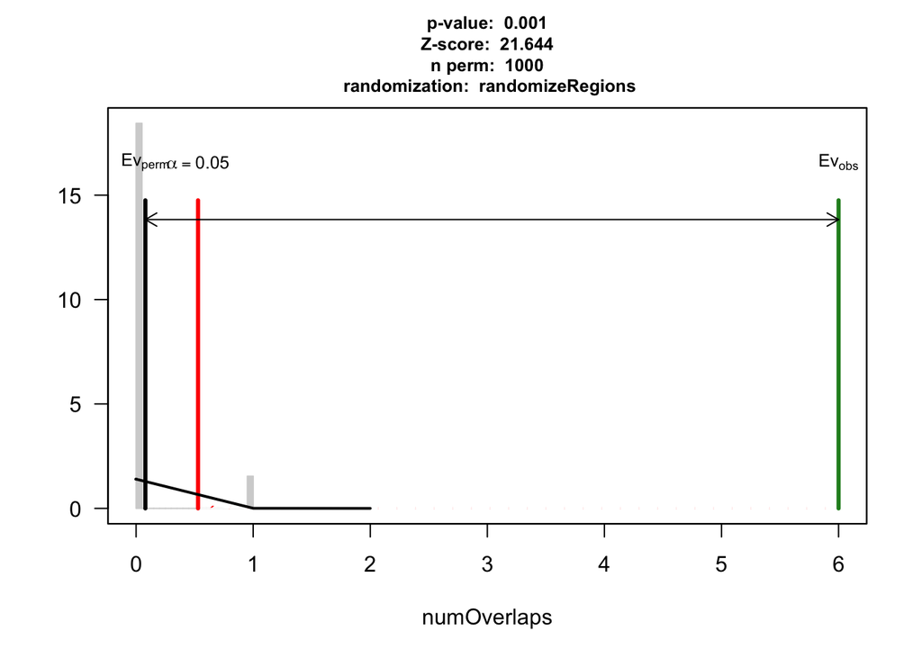

```r
# Run perm test using the permTest function
set.seed(492357816)
perm_hits1_result = suppressWarnings({
  permTest(A = hits1, B = hits2, ntimes = 1000,
           randomize.function = randomizeRegions,
           evaluate.function = numOverlaps)
})
plot(perm_hits1_result)
```

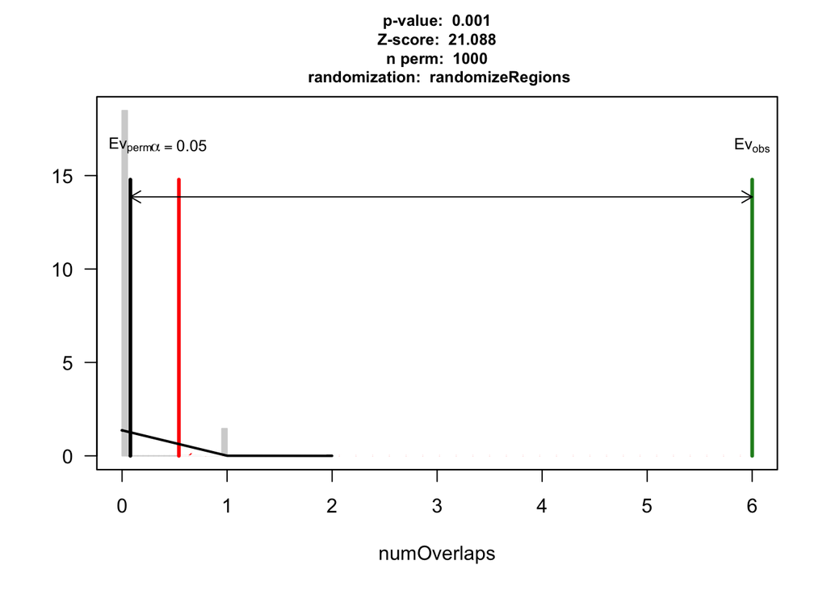

```r
set.seed(492357816)
perm_hits2_result = suppressWarnings({
  permTest(A = hits2, B = hits1, ntimes = 1000,
           randomize.function = randomizeRegions,
           evaluate.function = numOverlaps)
})
plot(perm_hits2_result)
```

```r
# Run perm test using the self-defined function
set.seed(492357816)
hits1_overlap_list = vector()
hits2_overlap_list = vector()
for(i in 1:1000){
  random_gr = suppressWarnings({randomizeRegions(hits1, genome = "hg19")})
  hits1_overlap = numOverlaps(hits1, random_gr)
  hits2_overlap = numOverlaps(hits2, random_gr)
  hits1_overlap_list = c(hits1_overlap_list, hits1_overlap)
  hits2_overlap_list = c(hits2_overlap_list, hits2_overlap)
}

self_perm_result = t.test(hits1_overlap_list, hits2_overlap_list)

perm_hits1_result
```

```
## $numOverlaps
## P-value: 0.000999000999000999
## Z-score: 21.6444
## Number of iterations: 1000
## Alternative: greater
## Evaluation of the original region set: 6
## Evaluation function: numOverlaps
## Randomization function: randomizeRegions
##
## attr(,"class")
## [1] "permTestResultsList"
```

```r
perm_hits2_result
```

```
## $numOverlaps
## P-value: 0.000999000999000999
## Z-score: 21.0876
## Number of iterations: 1000
## Alternative: greater
## Evaluation of the original region set: 6
## Evaluation function: numOverlaps
## Randomization function: randomizeRegions
##
## attr(,"class")
## [1] "permTestResultsList"
```

```r
self_perm_result
```

```
##
##  Welch Two Sample t-test
##
## data:  hits1_overlap_list and hits2_overlap_list
## t = -4.523, df = 1662.1, p-value = 6.529e-06
## alternative hypothesis: true difference in means is not equal to 0
## 95 percent confidence interval:
##  -0.06451423 -0.02548577
## sample estimates:
## mean of x mean of y
##     0.028     0.073
```

```r
# t.test(width(hits1), width(hits2))
mean(width(hits1)) * dim(hits1_df)[1]
```

```
## [1] 435651
```

```r
mean(width(hits2)) * dim(hits2_df)[1]
```

```
## [1] 626948
```

The difference can be explained by the comparison of the product of average region width and region count. hits1 regions are on average wider but there are significantly more regions in hits2, making hits2 cover a broader genomic region in general and therefore landing more hits by chance.

The smallest p-value that we could have gotten is zero, given that the number of resamples is ~infinitely large.

```r
run_perm_test = function(random_seed = 492357816){
  set.seed(random_seed)
  hits1_overlap_list = vector()
  hits2_overlap_list = vector()
  for(i in 1:1000){
    random_gr = suppressWarnings({randomizeRegions(hits1, genome = "hg19")})
    hits1_overlap = numOverlaps(hits1, random_gr)
    hits2_overlap = numOverlaps(hits2, random_gr)
    hits1_overlap_list = c(hits1_overlap_list, hits1_overlap)
    hits2_overlap_list = c(hits2_overlap_list, hits2_overlap)
  }
  self_perm_result = t.test(hits1_overlap_list, hits2_overlap_list)
  print(self_perm_result)
}

run_perm_test(43479)
```

```
##
##  Welch Two Sample t-test
##
## data:  hits1_overlap_list and hits2_overlap_list
## t = -3.6496, df = 1732.4, p-value = 0.0002704
## alternative hypothesis: true difference in means is not equal to 0
## 95 percent confidence interval:
##  -0.05995906 -0.01804094
## sample estimates:
## mean of x mean of y
##     0.036     0.075
```

```r
run_perm_test(89669)
```

```
##
##  Welch Two Sample t-test
##
## data:  hits1_overlap_list and hits2_overlap_list
## t = -2.3372, df = 1898.4, p-value = 0.01953
## alternative hypothesis: true difference in means is not equal to 0
## 95 percent confidence interval:
##  -0.045978341 -0.004021659
## sample estimates:
## mean of x mean of y
##     0.044     0.069
```

```r
run_perm_test(91617)
```

```
##
##  Welch Two Sample t-test
##
## data:  hits1_overlap_list and hits2_overlap_list
## t = -1.4888, df = 1949.6, p-value = 0.1367
## alternative hypothesis: true difference in means is not equal to 0
## 95 percent confidence interval:
##  -0.03707604  0.00507604
## sample estimates:
## mean of x mean of y
##     0.049     0.065
```

Here three different random seeds are used to run the permutation test. Although the effect size is consistantly negative, it seems to fluctuate between -1.5 to -3.6. This is to say that, given large enough numbers of resamples, random seeds will not change the overlap direction of the test. However, as the number of resamples get larger, the test statistics will become more stable (p-value more significant). On the contrary, when the number of resamples get smaller, the test statistics will be more volatile.

**Q5. Repeat Q4 switching the roles of hits1 and hits2. Are conclusions similar?**

```r
set.seed(492357816)
hits1_overlap_list = vector()
hits2_overlap_list = vector()
for(i in 1:1000){
  random_gr = suppressWarnings({randomizeRegions(hits2, genome = "hg19")})
  hits1_overlap = numOverlaps(hits1, random_gr)
  hits2_overlap = numOverlaps(hits2, random_gr)
  hits1_overlap_list = c(hits1_overlap_list, hits1_overlap)
  hits2_overlap_list = c(hits2_overlap_list, hits2_overlap)
}

self_perm_result = t.test(hits1_overlap_list, hits2_overlap_list)
self_perm_result
```

```
##
##  Welch Two Sample t-test
##
## data:  hits1_overlap_list and hits2_overlap_list
## t = -4.2223, df = 1808.5, p-value = 2.538e-05
## alternative hypothesis: true difference in means is not equal to 0
## 95 percent confidence interval:
##  -0.08640559 -0.03159441
## sample estimates:
## mean of x mean of y
##     0.071     0.130
```

The conclusions are relatively similar. This suggests that the chances of a randomly generated region overlapping with two genomic regions of interest is largely dependently on the overall size of the regions of interests.

**Q6. Create a random bootstrap sample of regions from all tested regions.**  
- Do these random regions overlap hits2 more or less than hits1 does?  
- How does this test differ from the one in Q4? Look at the z-score and p-value.

These random regions overlap hits2 more than hits1 does. reasons explained in the previous question. The p values are comparible but the z score is smaller in this test than what was implemented in the previous tests.

```r
set.seed(492357816)
btsp_hits1_result = permTest(A = hits1, B = hits2, ntimes = 1000,
                             randomize.function = resampleRegions,
                             universe = all,
                             evaluate.function = numOverlaps)
btsp_hits1_result
```

```
## $numOverlaps
## P-value: 0.000999000999000999
## Z-score: -4.1519
## Number of iterations: 1000
## Alternative: less
## Evaluation of the original region set: 6
## Evaluation function: numOverlaps
## Randomization function: resampleRegions
##
## attr(,"class")
## [1] "permTestResultsList"
```

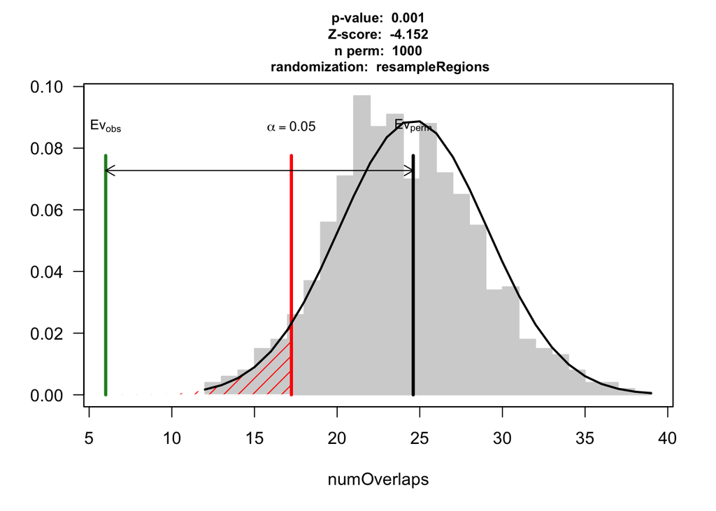

```r
plot(btsp_hits1_result)
```

**Q7. Repeat Q6 switching the role of hits1 and hits2. Are conclusions similar?**

The conclusion is very similar.

```r
set.seed(492357816)
btsp_hits2_result = permTest(A = hits2, B = hits1, ntimes = 1000,
                             randomize.function = resampleRegions,
                             universe = all,
                             evaluate.function = numOverlaps)
btsp_hits2_result
```

```
## $numOverlaps
## P-value: 0.000999000999000999
## Z-score: -4.1745
## Number of iterations: 1000
## Alternative: less
## Evaluation of the original region set: 6
## Evaluation function: numOverlaps
## Randomization function: resampleRegions
##
## attr(,"class")
## [1] "permTestResultsList"
```

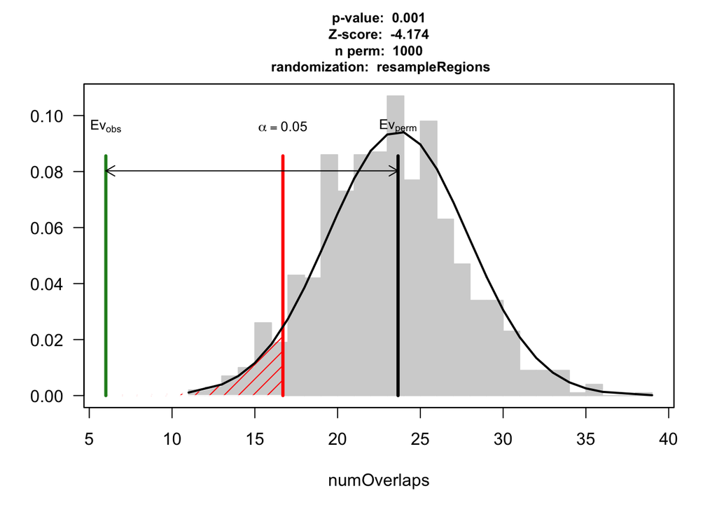

```r
plot(btsp_hits2_result)
```

**Q8. Which null distribution would you use in your own research and why?**

If my research primarily concerns regions of interests in hits1, then I would use the NULL distribution generated based on hits1. If I primarily focus on hits2, then I would use the NULL distro simulated using hits2. This way, I can get the most accurate depiction of the distribution of my own regions of interests.

The next few questions involve downloading genomics data. You can choose sets of regions, e.g, gene annotation, ChIPseq, RNAseq, ATACseq, GWAS SNPs

**Q9. Using data you download, can you infer what function was tested in the assay that discovered hits1 and hits2? Choose data sets that will be informative about candidate functions. Compute overlaps or mean values of the downloaded data for the union of hits1 and hits2**

data DOI: doi:10.17989/ENCSR000AHO

Human gene annotation file is downloaded from: https://www.gencodegenes.org/human/

```r
# Clean the dataset
# gtf = fread("gencode.v44.annotation.gtf")
# save(gtf, file = "gtf.rda")
load("gtf.rda")
gtf = as.data.frame(gtf)

names(gtf) = c("chr", "db", "gene", "start", "end", "v6", "strand", "v8", "anno")
gtf = gtf %>%
  select(chr, db, gene, start, end, anno) %>%
  filter(gene == "gene") %>%
  filter(db == "ENSEMBL")

gene_name = strsplit(gtf$anno, split = "gene_name") %>%
  lapply(function(x){x[2]}) %>%
  unlist() %>%
  strsplit(split = ";") %>%
  lapply(function(x){x[1]}) %>%
  unlist() %>%
  gsub(pattern = "\"", replacement = "") %>%
  gsub(pattern = " ", replacement = "")

gtf = gtf %>%
  mutate(gene_name = gene_name) %>%
  select(chr, db, gene, start, end, gene_name, anno) %>%
  mutate(pos = paste(chr, start, end, sep = "_"))

anno = GRanges(
  seqnames = Rle(gtf$chr),
  ranges = IRanges(start = gtf$start, end = gtf$end),
  strand = "*",
  metadata = tibble(
    gene_name = gtf$gene_name,
    pos = gtf$pos
  )
)

anno_df = as.data.frame(anno)

encode = toGRanges(read.table("ENCFF360QRN.bed",sep="\t"))
overlapRegions(hits1, encode)
```

```
##     chr    startA      endA    startB      endB    type
## 1  chr1 164668592 164669823 164669155 164669238    BinA
## 2 chr10  80980316  80984042  80982516  80982606    BinA
## 3 chr10  88443829  88449326  88446876  88447006    BinA
## 4  chr8  11557315  11561006  11556448  11558026 ArightB
## 5  chr8  11557315  11561006  11558460  11559025    BinA
## 6  chr8  11596784  11601556  11599273  11599343    BinA
## 7  chr8  11596784  11601556  11600792  11600862    BinA
## 8  chr8  30135042  30138909  30137886  30137956    BinA
```

```r
overlapRegions(hits2, encode)
```

```
##      chr    startA      endA    startB      endB    type
## 1  chr10 119309200 119310544 119309733 119309846    BinA
## 2  chr12  17171711  17174776  17173750  17173820    BinA
## 3  chr13  72425787  72428335  72425766  72425836 ArightB
## 4  chr15  31595790  31600208  31599857  31599943    BinA
## 5  chr15  31595790  31600208  31600000  31600276  AleftB
## 6   chr2   5549618   5553025   5550707   5550788    BinA
## 7   chr3 147563409 147566604 147565724 147565820    BinA
## 8   chr3  28033828  28035751  28035212  28035392    BinA
## 9   chr5 101999073 102003903 102003310 102003382    BinA
## 10  chr5 125344507 125346243 125345256 125345342    BinA
## 11  chr5  76940836  76941396  76940883  76940953    BinA
## 12  chr6  99089361  99091043  99090257  99090327    BinA
## 13  chr7 127174386 127177546 127176743 127176813    BinA
## 14  chr7 127174386 127177546 127177350 127177420    BinA
## 15  chr9  13750115  13751398  13748394  13750136 ArightB
```

```r
overlap_hits_encode = overlapRegions(mergeRegions(hits1, hits2), encode)
annotated = overlapRegions(overlap_hits_encode, anno)
annotated = as.data.frame(annotated) %>%
  mutate(metadata.pos = paste(chr, startB, endB, sep = "_")) %>%
  left_join(anno_df, by = "metadata.pos") %>%
  select(chr, startA, endA, metadata.gene_name)

annotated$metadata.gene_name
```

```
## character(0)
```

**Guess what type of genomic element these hits are (i.e., what assay was performed))**

Based on the fact that the study is a ChIP seq dataset, the overlapped regions are most likely Transcription factor genes.

**BONUS Q10. Do you think hits1 and hits2 function in the same cell type?**  
- Build on your analysis in Q9 by separately testing overlaps with hits1 and hits2. Choose datasets that are from several different cell types

```r
overlapRegions(hits1, encode)
```

```
##     chr    startA      endA    startB      endB    type
## 1  chr1 164668592 164669823 164669155 164669238    BinA
## 2 chr10  80980316  80984042  80982516  80982606    BinA
## 3 chr10  88443829  88449326  88446876  88447006    BinA
## 4  chr8  11557315  11561006  11556448  11558026 ArightB
## 5  chr8  11557315  11561006  11558460  11559025    BinA
## 6  chr8  11596784  11601556  11599273  11599343    BinA
## 7  chr8  11596784  11601556  11600792  11600862    BinA
## 8  chr8  30135042  30138909  30137886  30137956    BinA
```

```r
overlapRegions(hits2, encode)
```

```
##      chr    startA      endA    startB      endB    type
## 1  chr10 119309200 119310544 119309733 119309846    BinA
## 2  chr12  17171711  17174776  17173750  17173820    BinA
## 3  chr13  72425787  72428335  72425766  72425836 ArightB
## 4  chr15  31595790  31600208  31599857  31599943    BinA
## 5  chr15  31595790  31600208  31600000  31600276  AleftB
## 6   chr2   5549618   5553025   5550707   5550788    BinA
## 7   chr3 147563409 147566604 147565724 147565820    BinA
## 8   chr3  28033828  28035751  28035212  28035392    BinA
## 9   chr5 101999073 102003903 102003310 102003382    BinA
## 10  chr5 125344507 125346243 125345256 125345342    BinA
## 11  chr5  76940836  76941396  76940883  76940953    BinA
## 12  chr6  99089361  99091043  99090257  99090327    BinA
## 13  chr7 127174386 127177546 127176743 127176813    BinA
## 14  chr7 127174386 127177546 127177350 127177420    BinA
## 15  chr9  13750115  13751398  13748394  13750136 ArightB
```

```r
overlapRegions(hits1, anno) %>%
  as.data.frame() %>%
  mutate(metadata.pos = paste(chr, startB, endB, sep = "_")) %>%
  left_join(anno_df, by = "metadata.pos") %>%
  select(chr, startA, endA, metadata.gene_name)
```

```
##    chr   startA     endA metadata.gene_name
## 1 chr1 11906876 11908666            RNU5E-1
## 2 chr2 69103240 69108615            MIR3126
```

```r
overlapRegions(hits2, anno) %>%
  as.data.frame() %>%
  mutate(metadata.pos = paste(chr, startB, endB, sep = "_")) %>%
  left_join(anno_df, by = "metadata.pos") %>%
  select(chr, startA, endA, metadata.gene_name)
```

```
##     chr   startA     endA metadata.gene_name
## 1 chr16 51671181 51672039          RN7SKP142
## 2  chr9 92292484 92293889            MIR3651
## 3  chr9 92292484 92293889            SNORA84
```

Preparing for gene ontology enrichment analysis.

```r
hits1_genes = overlapRegions(hits1, anno) %>%
  as.data.frame() %>%
  mutate(metadata.pos = paste(chr, startB, endB, sep = "_")) %>%
  left_join(anno_df, by = "metadata.pos") %>%
  select(chr, startA, endA, metadata.gene_name)

hits2_genes = overlapRegions(hits2, anno) %>%
  as.data.frame() %>%
  mutate(metadata.pos = paste(chr, startB, endB, sep = "_")) %>%
  left_join(anno_df, by = "metadata.pos") %>%
  select(chr, startA, endA, metadata.gene_name)

hits1_genes = hits1_genes$metadata.gene_name
hits2_genes = hits2_genes$metadata.gene_name

# paste(unique(hits1_genes), collapse = "\n") %>% cat()
# paste(unique(hits2_genes), collapse = "\n") %>% cat()
```

**BONUS Q11: Try matching the random regions more closely to regions in hits1**  
- On what variables will you match them? e.g., spacing, chromosome, GC-content, distance to nearest gene, masking  
- How does matching affect the z-score and p-value?

If I were to match the random regions more closely with regions in hits1, I would try to match their spacing, GC-content, distance to nearest gene as well as genomic region (exonic, intronic, 3/5’ UTR etc.). Performing closer matching is predicted to increase the z score and making the p-value more significant. This is because closer matching reduces the degrees of freedom of selection of regions in the genome. Therefore making the selected random regions more likely to be similar to regions in hits1, which overlaps more with hits2.